# IODS course project

Hem Raj Bhattarai

# About the project

Right now i am feeling great becuase i have started something really new. I knew R exist and we could do lot of statistical analyses and data visulaization with it, but working with R and github togther is very amazing. From this course i am expecting to expand my basics of R with some new techniques on data visulaization. I got the information about this course from my colleague.

Link to my github repository is here :https://github.com/Hem-web/IODS-project

# chapter2: Regression and model validation

- This week course excersie will focus on Regression analyses and running the model for the data of our interest.
- Prior to regression and model validation, we looked deep into the data, understood it attributes and have worked with redefining name of some varibales and created a subset by seleccting variables of our interest for further analyses.

## Reading the data

```r
setwd("~/IODS-project")
learning2014 <- read.table("~/IODS-project/data/learning2014.txt")
str(learning2014)
```

```
## 'data.frame':    166 obs. of  7 variables:
##  $ gender  : Factor w/ 2 levels "F","M": 1 2 1 2 2 1 2 1 2 1 ...
##  $ age     : int  53 55 49 53 49 38 50 37 37 42 ...
##  $ attitude: num  3.7 3.1 2.5 3.5 3.7 3.8 3.5 2.9 3.8 2.1 ...
##  $ deep    : num  3.58 2.92 3.5 3.5 3.67 ...
##  $ stra    : num  3.38 2.75 3.62 3.12 3.62 ...
##  $ surf    : num  2.58 3.17 2.25 2.25 2.83 ...
##  $ points  : int  25 12 24 10 22 21 21 31 24 26 ...
```

```r
dim(learning2014)
```

```
## [1] 166   7
```

### Comment on structure and dimension of the data

- The data frame contains 7 variables with 166 observations where age and points are presented as integers and attitude, deep, stra and surf are presented as numbers.
- Gender is presented with two factor levels, male (M) and female (F).

## Exploring the data

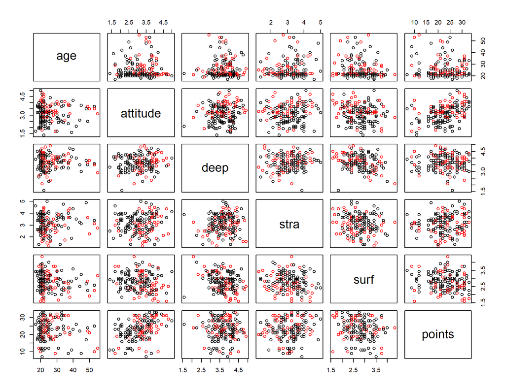

```r
pairs(learning2014[!names(learning2014) %in% c("gender")],col=learning2014$gender)
```

```r
library(GGally)
```

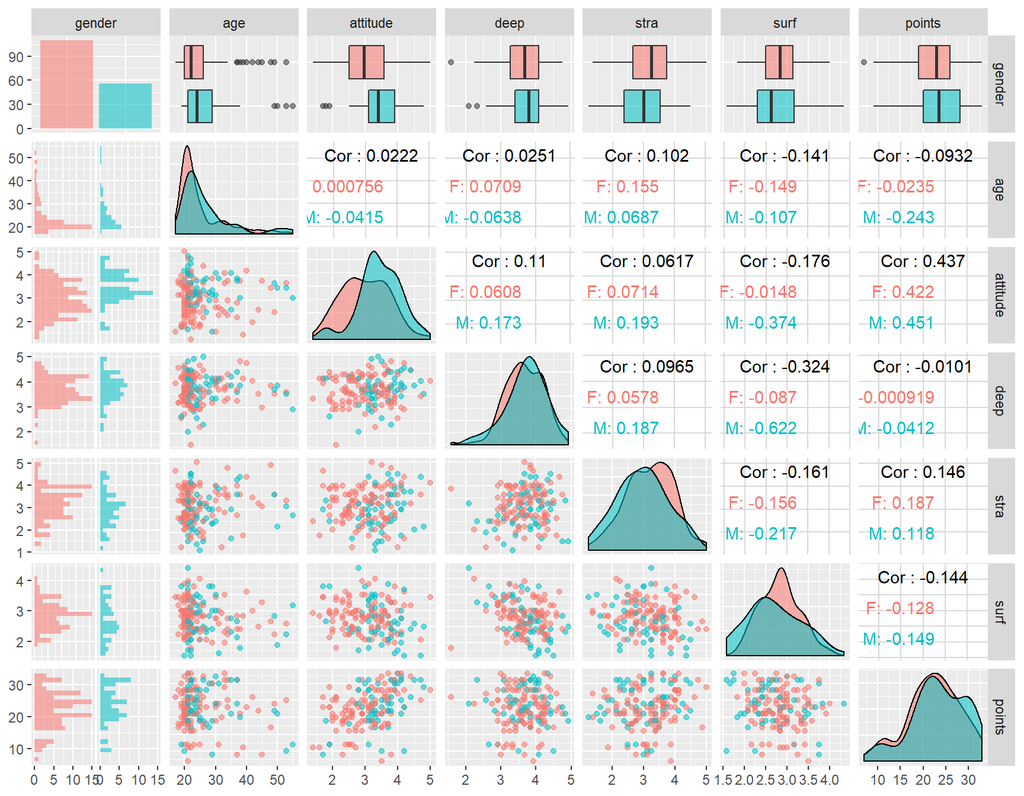

```r
library(ggplot2)
ggpairs(learning2014,
        mapping = aes(col = gender, alpha = 0.3),
        lower = list(combo = wrap("facethist", bins = 20)))
```

### Interpreting the data

- If we look at the main daiganol (skewed distribution) and first column (histograms), among all variables *age* of the gender is highly skewed whereas *stra* is skewed very minimal.
- High skeweness in age is also visible from box plots as it shows many outliers above whiskers (error bars). Minimal skweness in *stra* variable could be also seen in the box plot of *stra* where medians for both genders lies almost at the center of the box.
- Highest correlation is seen between *attitude* and *points*; **Cor:** 0.4365245 .
- Lowest correlation is seen between *deep* and *surf*; **Cor:** -0.323802 .

## Linear Regression

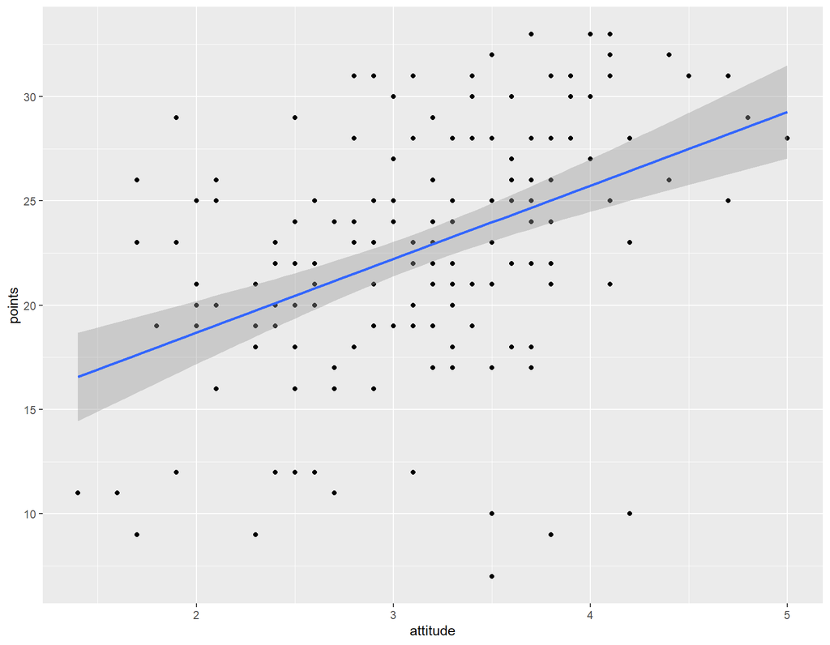

```r
qplot(attitude, points, data = learning2014) + geom_smooth(method = "lm")
```

Running the regression model with all five independent variables, *attitude*, *surf*, *stra*, *age*, and *deep* to identify the strongest impact of them on *points*.

```r
my_model <- lm(points ~ attitude + surf + deep + stra + age, data = learning2014)
results <- summary(my_model)

knitr::kable(results$coefficients, digits=3, caption="Regression coefficients")
```

Regression coefficients

|  | Estimate | Std. Error | t value | Pr(>\|t\|) |
| --- | --- | --- | --- | --- |
| (Intercept) | 18.301 | 5.241 | 3.492 | 0.001 |
| attitude | 3.432 | 0.570 | 6.022 | 0.000 |
| surf | -1.105 | 0.840 | -1.316 | 0.190 |
| deep | -1.044 | 0.782 | -1.335 | 0.184 |
| stra | 0.966 | 0.539 | 1.791 | 0.075 |
| age | -0.097 | 0.053 | -1.809 | 0.072 |

After running the model with five explanatory variables, we observed that the strongest effect on score *points* was due to attitude towards statistics. Nevertheless, let’s remove *stra*, *age*, and *deep* and run the model again to see if including *surf* in the model makes any changes.

```r
my_model1 <- lm(points ~ attitude + surf, data = learning2014)
results <- summary(my_model1)

knitr::kable(results$coefficients, digits=3, caption="Regression coefficients")
```

Regression coefficients

|  | Estimate | Std. Error | t value | Pr(>\|t\|) |
| --- | --- | --- | --- | --- |
| (Intercept) | 14.120 | 3.127 | 4.515 | 0.000 |
| attitude | 3.426 | 0.576 | 5.944 | 0.000 |
| surf | -0.779 | 0.796 | -0.979 | 0.329 |

```r
my_model3 <- lm(points ~ attitude, data = learning2014)
results <- summary(my_model3)

knitr::kable(results$coefficients, digits=3, caption="Regression coefficients")
```

Regression coefficients

|  | Estimate | Std. Error | t value | Pr(>\|t\|) |
| --- | --- | --- | --- | --- |
| (Intercept) | 11.637 | 1.830 | 6.358 | 0 |
| attitude | 3.525 | 0.567 | 6.214 | 0 |

The final model summay suggest that as intercept and attitude are statistically singnificant. The attitude estimate 3.525 means that in every 1 level increase of attiutde the point score will be increased by 3.525 whereas intercept of 11.637 means that people with zero attitude can still get 11.637 points. The Coefficient of determination $R^2$ = 0.1905537 indicates that contribution of attitude towards scoring point is only 19%. This suggest that there must be other explanatory variables which could influence the *points*.

### Diagnostic plots

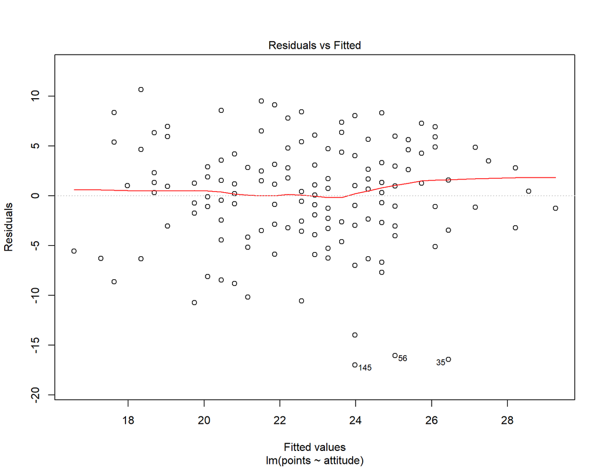

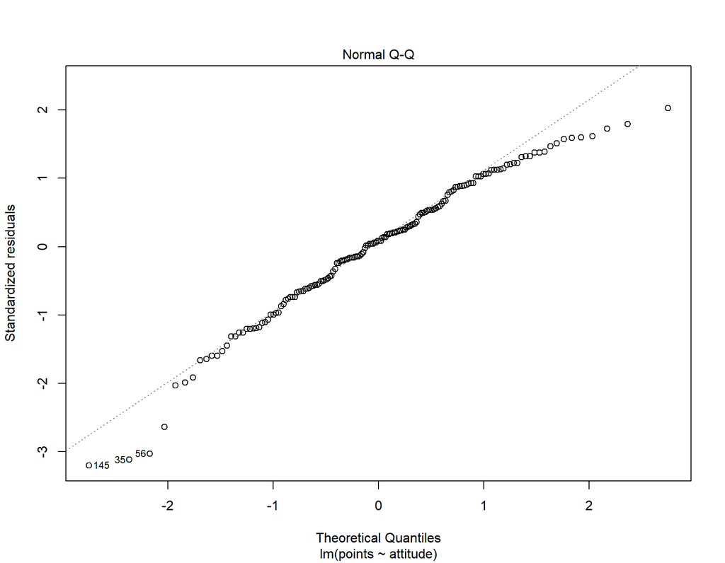

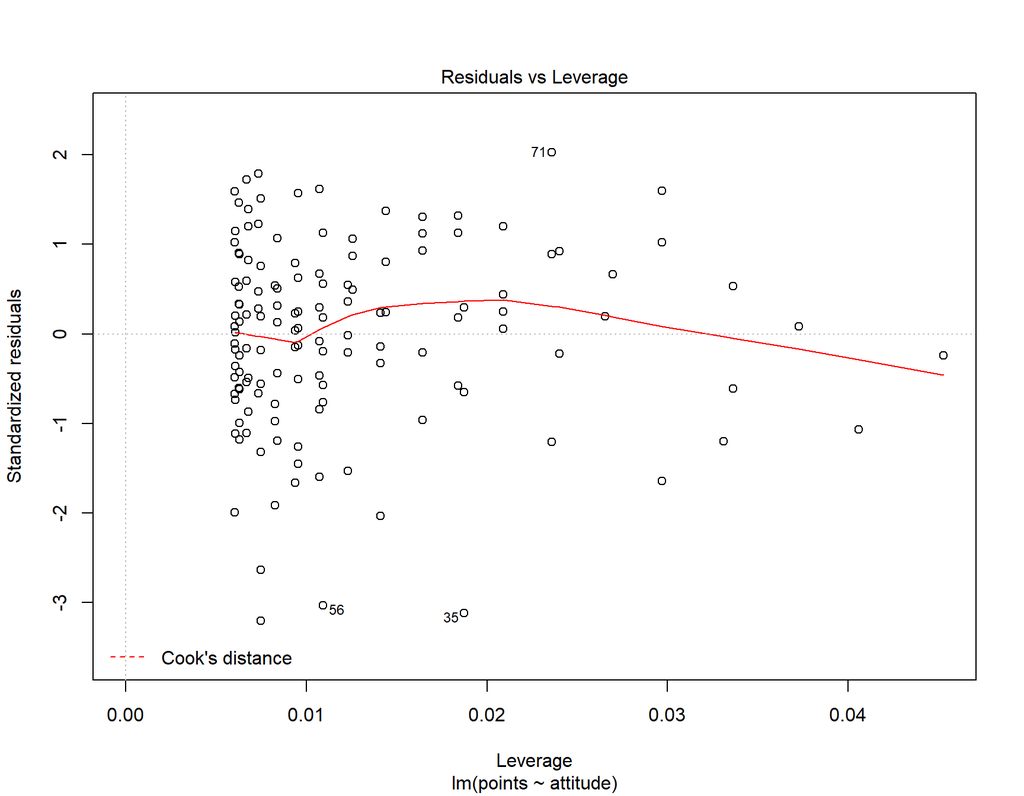

```r
plot(my_model3, which=c(1,2,5))
```

- Linear regression model is based on mainly two assumption, first, the linearity of the target variable is assumed to be linear and second, errors in the model are normally distributed with no correlation, contant variance and independent of expalanotry variables.
- Based on QQ plots we can say the our errors are close to normally distributed as dots falls closer to the line of fit.
- The uniform distribution of residuals vs model prediction, suggest that error size is constant and there is no effect of explanotry variable on it.
- The Residual vs leverage plot assist in identifying the extreme outliers in the explanotry variables. Any sort of trend on that plot will point towards an outlier. Since we do not see such trend in Residual vs leverage plot we can say that there was a regular leverage in out model.
- As our model was well fitted with the assumptions, we can conclude that our model is valid.

# chapter3:Logistic Regression

## Reading the data

```r
setwd("~/IODS-project")
alc <- read.table("~/IODS-project/data/pormath.txt")
names(alc)
```

```
##  [1] "school"     "sex"        "age"        "address"    "famsize"
##  [6] "Pstatus"    "Medu"       "Fedu"       "Mjob"       "Fjob"
## [11] "reason"     "nursery"    "internet"   "guardian"   "traveltime"
## [16] "studytime"  "failures"   "schoolsup"  "famsup"     "paid"
## [21] "activities" "higher"     "romantic"   "famrel"     "freetime"
## [26] "goout"      "Dalc"       "Walc"       "health"     "absences"
## [31] "G1"         "G2"         "G3"         "alc_use"    "high_use"
```

```r
str(alc)
```

```
## 'data.frame':    382 obs. of  35 variables:
##  $ school    : Factor w/ 2 levels "GP","MS": 1 1 1 1 1 1 1 1 1 1 ...
##  $ sex       : Factor w/ 2 levels "F","M": 1 1 1 1 1 2 2 1 2 2 ...
##  $ age       : int  18 17 15 15 16 16 16 17 15 15 ...
##  $ address   : Factor w/ 2 levels "R","U": 2 2 2 2 2 2 2 2 2 2 ...
##  $ famsize   : Factor w/ 2 levels "GT3","LE3": 1 1 2 1 1 2 2 1 2 1 ...
##  $ Pstatus   : Factor w/ 2 levels "A","T": 1 2 2 2 2 2 2 1 1 2 ...
##  $ Medu      : int  4 1 1 4 3 4 2 4 3 3 ...
##  $ Fedu      : int  4 1 1 2 3 3 2 4 2 4 ...
##  $ Mjob      : Factor w/ 5 levels "at_home","health",..: 1 1 1 2 3 4 3 3 4 3 ...
##  $ Fjob      : Factor w/ 5 levels "at_home","health",..: 5 3 3 4 3 3 3 5 3 3 ...
##  $ reason    : Factor w/ 4 levels "course","home",..: 1 1 3 2 2 4 2 2 2 2 ...
##  $ nursery   : Factor w/ 2 levels "no","yes": 2 1 2 2 2 2 2 2 2 2 ...
##  $ internet  : Factor w/ 2 levels "no","yes": 1 2 2 2 1 2 2 1 2 2 ...
##  $ guardian  : Factor w/ 3 levels "father","mother",..: 2 1 2 2 1 2 2 2 2 2 ...
```

[output cut: 21 more lines]

## Development of hypothesis based on selected variables

- There are many interesting variables in the data which could strongly link to the alcohol consumption rate.However, I find followings varibales quite interesting and propose my personal hypothesis for each of them in reagrds with alcohol consumption.
  - *grades*: Having low grades already in the first period could encourage alcohol consumption becuase low grades generally perceieved as failure.
  - *freetime*: More freetime after school could discourage alcohol consumption becuase it will assist on easing the stress that have likely accumulated during shool hours.
  - *studytime*: More study hours demands more focus. This will likely induce the feelings of having an extra mode of refreshment, therefore could encourage alcohol consumption
  - *absences*:Absences may are results of stress related things, not keen on studying etc. Absences in school means that student spent their times also doing something else than just studying. Therefore, more absences in school could be a sign of spending time for drinking alcohol.

## Exploring the distribution of selected variables and their relationships with alcohol consumption

- To explore the distribution of selected variables lets first install the following packages from library.

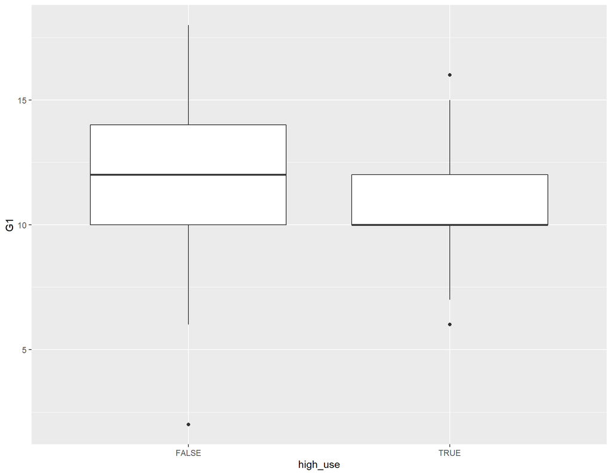

```r
library(ggplot2)
library(dplyr)
#For graphical distribution I will use box plots of variables against the alcohol consumptions between male and female students. For that let's run following script
g1 <- ggplot(alc, aes(x = high_use, y = G1))
g1 + geom_boxplot() + ylab("G1")
```

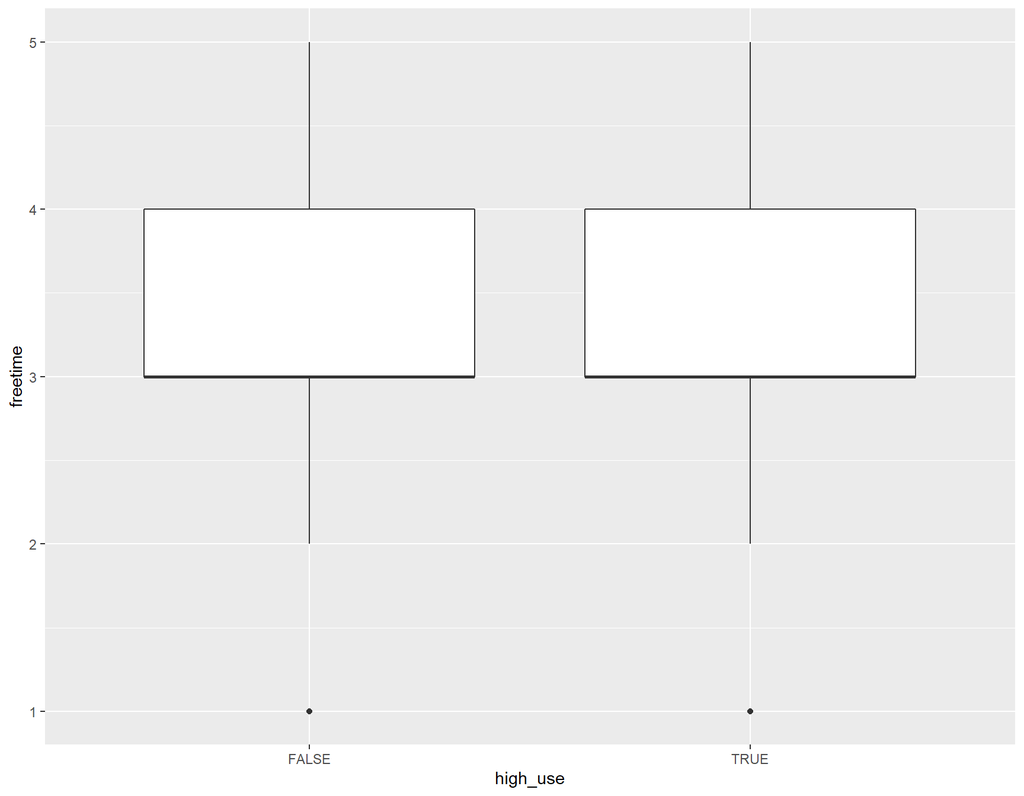

```r
g2 <- ggplot(alc, aes(x = high_use, y = freetime))
g2 + geom_boxplot() + ylab("freetime")
```

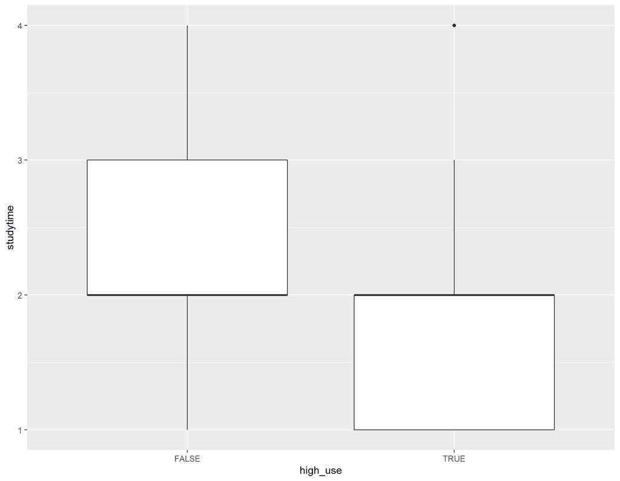

```r
g3 <- ggplot(alc, aes(x = high_use, y = studytime))
g3 + geom_boxplot() + ylab("studytime")
```

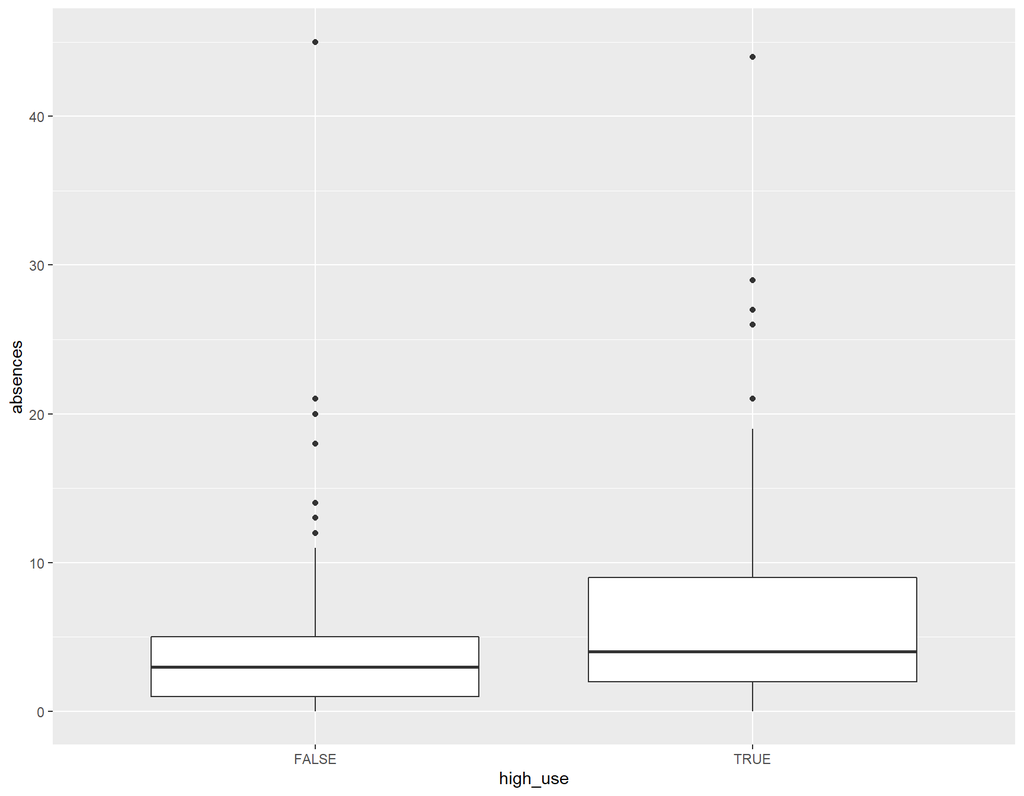

```r
g3 <- ggplot(alc, aes(x = high_use, y = absences))
g3 + geom_boxplot() + ylab("absences")
```

## Performing regression analyses on selected variables and alcohol consumption

```r
m <- glm(high_use ~ G1 + freetime + studytime + absences, data = alc, family = "binomial")
summary(m)
```

```
##
## Call:
## glm(formula = high_use ~ G1 + freetime + studytime + absences,
##     family = "binomial", data = alc)
##
## Deviance Residuals:
##    Min      1Q  Median      3Q     Max
## -1.885  -0.828  -0.634   1.110   2.129
##
## Coefficients:
##             Estimate Std. Error z value Pr(>|z|)
## (Intercept) -0.49537    0.72601  -0.682 0.495036
## G1          -0.08391    0.04591  -1.828 0.067614 .
## freetime     0.33103    0.12468   2.655 0.007929 **
## studytime   -0.45144    0.15958  -2.829 0.004671 **
## absences     0.07957    0.02245   3.544 0.000395 ***
## ---
## Signif. codes:  0 '***' 0.001 '**' 0.01 '*' 0.05 '.' 0.1 ' ' 1
##
## (Dispersion parameter for binomial family taken to be 1)
##
##     Null deviance: 465.68  on 381  degrees of freedom
## Residual deviance: 423.08  on 377  degrees of freedom
## AIC: 433.08
##
## Number of Fisher Scoring iterations: 4
```

```r
coef(m)
```

```
## (Intercept)          G1    freetime   studytime    absences
## -0.49536973 -0.08390687  0.33102562 -0.45144113  0.07956876
```

```r
OR <- coef(m) %>% exp
CI<-confint(m)
cbind(OR, CI)
```

```
##                    OR       2.5 %       97.5 %
## (Intercept) 0.6093456 -1.92821285  0.925191583
## G1          0.9195169 -0.17508225  0.005453013
## freetime    1.3923955  0.08987902  0.579750936
## studytime   0.6367099 -0.77323579 -0.146089296
## absences    1.0828200  0.03763152  0.126082337
```

## Exploring the predictive power of the model

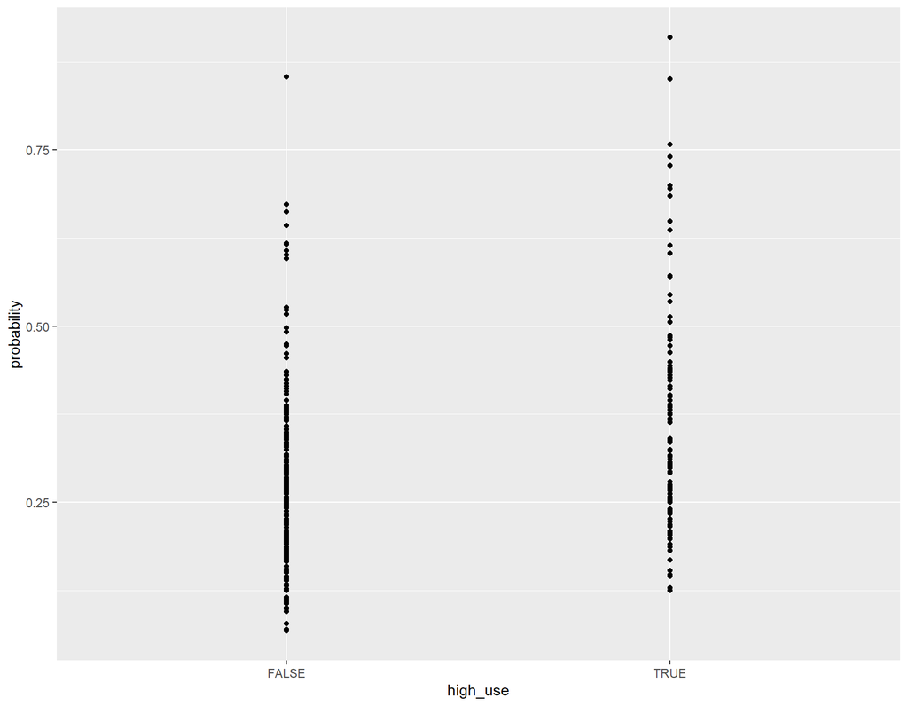

```r
# fit the model
m <- glm(high_use ~ G1 + freetime + absences, data = alc, family = "binomial")

# predict() the probability of high_use
probabilities <- predict(m, type = "response")

# add the predicted probabilities to 'alc'
alc <- mutate(alc, probability = probabilities)

# use the probabilities to make a prediction of high_use
alc <- mutate(alc, prediction = high_use)
# initialize a plot of 'high_use' versus 'probability' in 'alc'
g <- ggplot(alc, aes(x = high_use, y = probability))

# define the geom as points and draw the plot
g + geom_point()
```

```r
# tabulate the target variable versus the predictions
table(high_use = alc$high_use, prediction = alc$prediction)
```

```
##         prediction
## high_use FALSE TRUE
##    FALSE   268    0
##    TRUE      0  114
```

```r
# define a loss function (mean prediction error)
loss_func <- function(class, prob) {
  n_wrong <- abs(class - prob) > 0.5
  mean(n_wrong)
}

# call loss_func to compute the average number of wrong predictions in the (training) data
loss_func(class = alc$high_use, prob = 0)
```

```
## [1] 0.2984293
```

# Chapter4: Clustering and Classification

- In this chapter we are going to learn about methods that help us to identify the clusters (obersavtionsthat falls in one point or not homogenous) via clustering and classifying (giving names) and interpreting them based on their clusters structures or forms via classification method.
- *K-means clustering* is most typical technique used to identify clustered observations in the data. Also *hierarchical clustering* methods is quite popular, giving tree-like dendrograms as their main output.
- Presence or absence of clusters in the data is easy to identify but knowing more e.g how many, giving names etc is not that easy.
- Knowing more about clusters after identifying them is done by using different form of analysis e.g. *discriminant analysis* which operates with the (now) known clusters, asking: “what makes the difference(s) between these groups (clusters)?”
- Additionally, *distance* (or dissimilarity or similarity) approach on classifying clusters will be also discussed. updateR()

## Reading the data

```
##       crim                zn             indus            chas
##  Min.   : 0.00632   Min.   :  0.00   Min.   : 0.46   Min.   :0.00000
##  1st Qu.: 0.08204   1st Qu.:  0.00   1st Qu.: 5.19   1st Qu.:0.00000
##  Median : 0.25651   Median :  0.00   Median : 9.69   Median :0.00000
##  Mean   : 3.61352   Mean   : 11.36   Mean   :11.14   Mean   :0.06917
##  3rd Qu.: 3.67708   3rd Qu.: 12.50   3rd Qu.:18.10   3rd Qu.:0.00000
##  Max.   :88.97620   Max.   :100.00   Max.   :27.74   Max.   :1.00000
##       nox               rm             age              dis
##  Min.   :0.3850   Min.   :3.561   Min.   :  2.90   Min.   : 1.130
##  1st Qu.:0.4490   1st Qu.:5.886   1st Qu.: 45.02   1st Qu.: 2.100
##  Median :0.5380   Median :6.208   Median : 77.50   Median : 3.207
##  Mean   :0.5547   Mean   :6.285   Mean   : 68.57   Mean   : 3.795
##  3rd Qu.:0.6240   3rd Qu.:6.623   3rd Qu.: 94.08   3rd Qu.: 5.188
##  Max.   :0.8710   Max.   :8.780   Max.   :100.00   Max.   :12.127
##       rad              tax           ptratio          black
##  Min.   : 1.000   Min.   :187.0   Min.   :12.60   Min.   :  0.32
##  1st Qu.: 4.000   1st Qu.:279.0   1st Qu.:17.40   1st Qu.:375.38
##  Median : 5.000   Median :330.0   Median :19.05   Median :391.44
##  Mean   : 9.549   Mean   :408.2   Mean   :18.46   Mean   :356.67
##  3rd Qu.:24.000   3rd Qu.:666.0   3rd Qu.:20.20   3rd Qu.:396.23
##  Max.   :24.000   Max.   :711.0   Max.   :22.00   Max.   :396.90
##      lstat            medv
##  Min.   : 1.73   Min.   : 5.00
##  1st Qu.: 6.95   1st Qu.:17.02
##  Median :11.36   Median :21.20
##  Mean   :12.65   Mean   :22.53
##  3rd Qu.:16.95   3rd Qu.:25.00
##  Max.   :37.97   Max.   :50.00
```

```
## [1] 506  14
```

```
## 'data.frame':    506 obs. of  14 variables:
##  $ crim   : num  0.00632 0.02731 0.02729 0.03237 0.06905 ...
##  $ zn     : num  18 0 0 0 0 0 12.5 12.5 12.5 12.5 ...
##  $ indus  : num  2.31 7.07 7.07 2.18 2.18 2.18 7.87 7.87 7.87 7.87 ...
##  $ chas   : int  0 0 0 0 0 0 0 0 0 0 ...
##  $ nox    : num  0.538 0.469 0.469 0.458 0.458 0.458 0.524 0.524 0.524 0.524 ...
##  $ rm     : num  6.58 6.42 7.18 7 7.15 ...
##  $ age    : num  65.2 78.9 61.1 45.8 54.2 58.7 66.6 96.1 100 85.9 ...
##  $ dis    : num  4.09 4.97 4.97 6.06 6.06 ...
##  $ rad    : int  1 2 2 3 3 3 5 5 5 5 ...
##  $ tax    : num  296 242 242 222 222 222 311 311 311 311 ...
##  $ ptratio: num  15.3 17.8 17.8 18.7 18.7 18.7 15.2 15.2 15.2 15.2 ...
##  $ black  : num  397 397 393 395 397 ...
##  $ lstat  : num  4.98 9.14 4.03 2.94 5.33 ...
##  $ medv   : num  24 21.6 34.7 33.4 36.2 28.7 22.9 27.1 16.5 18.9 ...
```

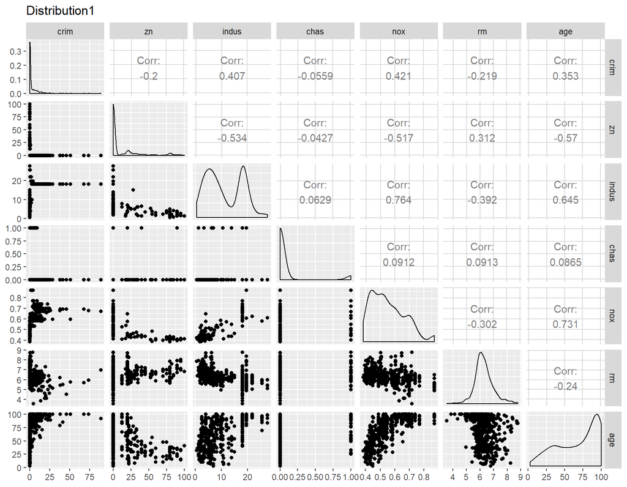

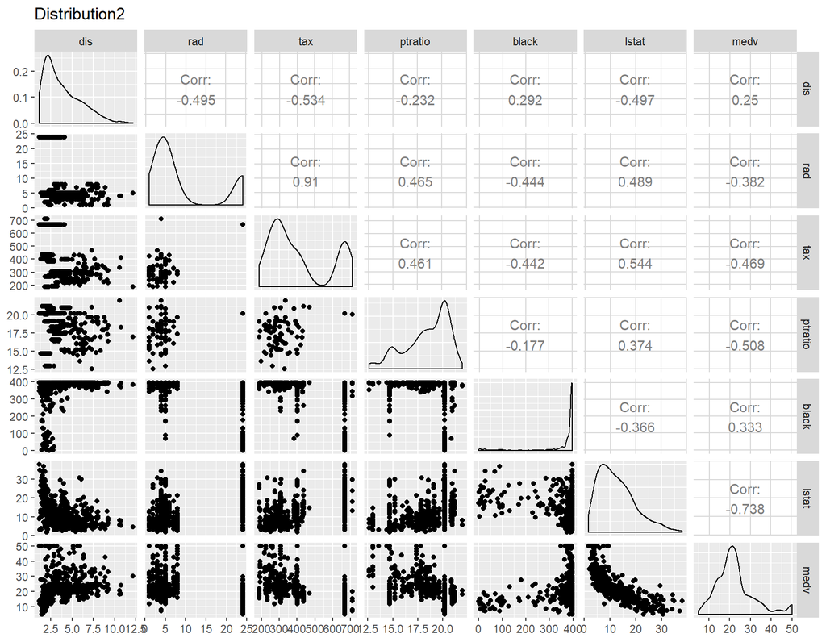

- Distribution of the variables:Looking in the both distribution figures all the variables are not homogenously distributed except ***rm** (average no of room per dewelling).
- Relationship between the variables:In the data *rad*(accessibility to radial highways) and *tax* shows a strong positive association as seen in the “Distribution2”. On the other hand in the same figure a similar but negative association is also seen between *Istat* and *medv*.

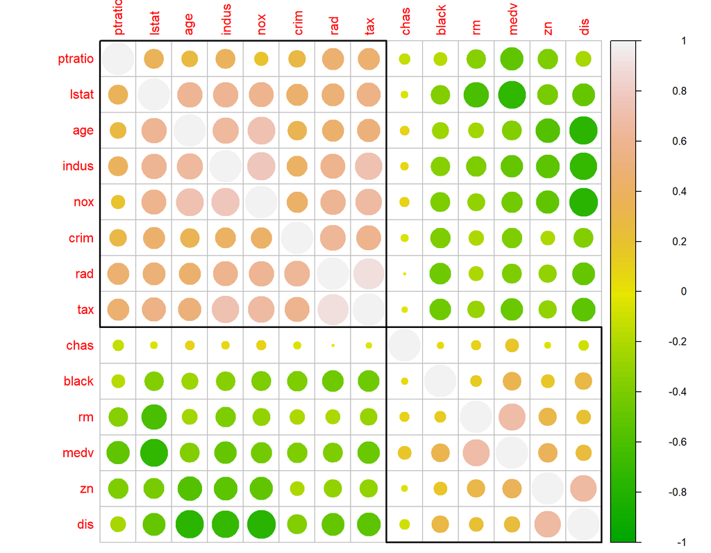

## Standarization of the data

- During standarization of the data we scale the variables so that their mean changes to zero and standard deviation is converted to 1.

```
##       crim                 zn               indus              chas
##  Min.   :-0.419367   Min.   :-0.48724   Min.   :-1.5563   Min.   :-0.2723
##  1st Qu.:-0.410563   1st Qu.:-0.48724   1st Qu.:-0.8668   1st Qu.:-0.2723
##  Median :-0.390280   Median :-0.48724   Median :-0.2109   Median :-0.2723
##  Mean   : 0.000000   Mean   : 0.00000   Mean   : 0.0000   Mean   : 0.0000
##  3rd Qu.: 0.007389   3rd Qu.: 0.04872   3rd Qu.: 1.0150   3rd Qu.:-0.2723
##  Max.   : 9.924110   Max.   : 3.80047   Max.   : 2.4202   Max.   : 3.6648
##       nox                rm               age               dis
##  Min.   :-1.4644   Min.   :-3.8764   Min.   :-2.3331   Min.   :-1.2658
##  1st Qu.:-0.9121   1st Qu.:-0.5681   1st Qu.:-0.8366   1st Qu.:-0.8049
##  Median :-0.1441   Median :-0.1084   Median : 0.3171   Median :-0.2790
##  Mean   : 0.0000   Mean   : 0.0000   Mean   : 0.0000   Mean   : 0.0000
##  3rd Qu.: 0.5981   3rd Qu.: 0.4823   3rd Qu.: 0.9059   3rd Qu.: 0.6617
##  Max.   : 2.7296   Max.   : 3.5515   Max.   : 1.1164   Max.   : 3.9566
##       rad               tax             ptratio            black
##  Min.   :-0.9819   Min.   :-1.3127   Min.   :-2.7047   Min.   :-3.9033
##  1st Qu.:-0.6373   1st Qu.:-0.7668   1st Qu.:-0.4876   1st Qu.: 0.2049
##  Median :-0.5225   Median :-0.4642   Median : 0.2746   Median : 0.3808
##  Mean   : 0.0000   Mean   : 0.0000   Mean   : 0.0000   Mean   : 0.0000
##  3rd Qu.: 1.6596   3rd Qu.: 1.5294   3rd Qu.: 0.8058   3rd Qu.: 0.4332
##  Max.   : 1.6596   Max.   : 1.7964   Max.   : 1.6372   Max.   : 0.4406
##      lstat              medv
##  Min.   :-1.5296   Min.   :-1.9063
##  1st Qu.:-0.7986   1st Qu.:-0.5989
##  Median :-0.1811   Median :-0.1449
##  Mean   : 0.0000   Mean   : 0.0000
##  3rd Qu.: 0.6024   3rd Qu.: 0.2683
##  Max.   : 3.5453   Max.   : 2.9865
```

```
## [1] "matrix"
```

```
##           0%          25%          50%          75%         100%
## -0.419366929 -0.410563278 -0.390280295  0.007389247  9.924109610
```

```
## crime
##      low  med_low med_high     high
##      127      126      126      127
```

```
## [1] 506  14
```

```
## 'data.frame':    506 obs. of  14 variables:
##  $ zn     : num  0.285 -0.487 -0.487 -0.487 -0.487 ...
##  $ indus  : num  -1.287 -0.593 -0.593 -1.306 -1.306 ...
##  $ chas   : num  -0.272 -0.272 -0.272 -0.272 -0.272 ...
##  $ nox    : num  -0.144 -0.74 -0.74 -0.834 -0.834 ...
##  $ rm     : num  0.413 0.194 1.281 1.015 1.227 ...
##  $ age    : num  -0.12 0.367 -0.266 -0.809 -0.511 ...
##  $ dis    : num  0.14 0.557 0.557 1.077 1.077 ...
##  $ rad    : num  -0.982 -0.867 -0.867 -0.752 -0.752 ...
##  $ tax    : num  -0.666 -0.986 -0.986 -1.105 -1.105 ...
##  $ ptratio: num  -1.458 -0.303 -0.303 0.113 0.113 ...
##  $ black  : num  0.441 0.441 0.396 0.416 0.441 ...
##  $ lstat  : num  -1.074 -0.492 -1.208 -1.36 -1.025 ...
##  $ medv   : num  0.16 -0.101 1.323 1.182 1.486 ...
##  $ crime  : Factor w/ 4 levels "low","med_low",..: 1 1 1 1 1 1 2 2 2 2 ...
```

- After scaling the variables, the mean value of each has now changed to zero.
- During standarization of data, we also created a categorical variable *crime* and uses the quantiles as break points and saved the scaled data as data frame.
- Following this we also divided the dataset into *train dataset* and *test dataset* so that 80 % o data belongs to first dataset. In *test dataset* variable *crime* is excluded just becuase that this variable will be used to define the classes that will help to generalize our results from train dataset.

```
## 'data.frame':    404 obs. of  14 variables:
##  $ zn     : num  0.413 -0.487 0.413 -0.487 -0.487 ...
##  $ indus  : num  -0.801 -0.437 -0.801 1.015 1.015 ...
##  $ chas   : num  -0.272 -0.272 -0.272 -0.272 -0.272 ...
##  $ nox    : num  -0.998 -0.144 -0.998 1.004 1.409 ...
##  $ rm     : num  -0.241 -0.498 -0.408 0.973 0.768 ...
##  $ age    : num  -0.198 -1.395 -1.676 0.829 0.282 ...
##  $ dis    : num  1.434 0.334 1.434 -1.13 -0.95 ...
##  $ rad    : num  -0.637 -0.637 -0.637 1.66 1.66 ...
##  $ tax    : num  -0.98 -0.601 -0.98 1.529 1.529 ...
##  $ ptratio: num  -0.765 1.175 -0.765 0.806 0.806 ...
##  $ black  : num  0.409 0.331 0.441 0.441 -3.376 ...
##  $ lstat  : num  -0.451 -0.85 -0.591 0.638 1.413 ...
##  $ medv   : num  -0.221 0.0617 0.0943 -1.3192 -1.5367 ...
##  $ crime  : Factor w/ 4 levels "low","med_low",..: 1 3 1 4 4 3 2 1 2 3 ...
```

```
## 'data.frame':    102 obs. of  13 variables:
##  $ zn     : num  -0.4872 0.0487 -0.4872 -0.4872 -0.4872 ...
##  $ indus  : num  -0.593 -0.476 -0.437 -0.437 -0.755 ...
##  $ chas   : num  -0.272 -0.272 -0.272 -0.272 -0.272 ...
##  $ nox    : num  -0.74 -0.265 -0.144 -0.144 -0.481 ...
##  $ rm     : num  0.194 -0.93 -0.976 -0.814 -0.453 ...
##  $ age    : num  0.367 1.116 0.608 0.907 -1.363 ...
##  $ dis    : num  0.5566 1.0861 0.3132 0.208 0.0248 ...
##  $ rad    : num  -0.867 -0.522 -0.637 -0.637 -0.522 ...
##  $ tax    : num  -0.986 -0.577 -0.601 -0.601 -0.767 ...
##  $ ptratio: num  -0.303 -1.504 1.175 1.175 0.344 ...
##  $ black  : num  0.4406 0.3281 -0.5833 0.0383 0.4026 ...
##  $ lstat  : num  -0.492 2.419 0.54 1.393 -0.353 ...
##  $ medv   : num  -0.101 -0.656 -0.939 -1.069 0.236 ...
```

## LDA

```
## Call:
## lda(crime ~ ., data = train)
##
## Prior probabilities of groups:
##       low   med_low  med_high      high
## 0.2574257 0.2475248 0.2450495 0.2500000
##
## Group means:
##                  zn      indus        chas        nox         rm        age
## low       1.0035649 -0.9405422 -0.08304540 -0.8981028  0.4760638 -0.9378675
## med_low  -0.1002740 -0.2816588 -0.03610305 -0.5574504 -0.1350869 -0.3022467
## med_high -0.4162114  0.2770404  0.16512651  0.4211328  0.0427147  0.4266584
## high     -0.4872402  1.0171306 -0.07742312  1.0690515 -0.4098266  0.8182928
##                 dis        rad        tax     ptratio       black       lstat
## low       0.9058061 -0.6803986 -0.7340693 -0.42360052  0.38469292 -0.78861172
## med_low   0.3361808 -0.5477507 -0.4372755 -0.05752274  0.31668121 -0.14346092
## med_high -0.3745248 -0.3913967 -0.2499511 -0.16655574  0.07268388  0.02954423
## high     -0.8565000  1.6379981  1.5139626  0.78062517 -0.90019456  0.92028170
##                 medv
## low       0.57061036
## med_low  -0.02139873
## med_high  0.08868863
## high     -0.73022710
##
## Coefficients of linear discriminants:
##                 LD1          LD2         LD3
## zn       0.10597815  0.670032502 -0.89233499
## indus    0.03441312 -0.450997752  0.03777075
## chas    -0.09539756 -0.027478134  0.11480318
## nox      0.38708510 -0.567016750 -1.49396865
## rm      -0.09672085 -0.066489857 -0.18116701
## age      0.32698395 -0.398814665 -0.07428592
## dis     -0.04508934 -0.274571271  0.04642799
## rad      2.99322741  0.980161214 -0.19093598
## tax     -0.05438365  0.017894863  0.86170147
## ptratio  0.13359658 -0.032134105 -0.33084475
## black   -0.14769449 -0.005347572  0.11590672
## lstat    0.21376122 -0.111248115  0.40586213
## medv     0.19931894 -0.288111190 -0.23362765
##
## Proportion of trace:
##    LD1    LD2    LD3
## 0.9402 0.0451 0.0147
```

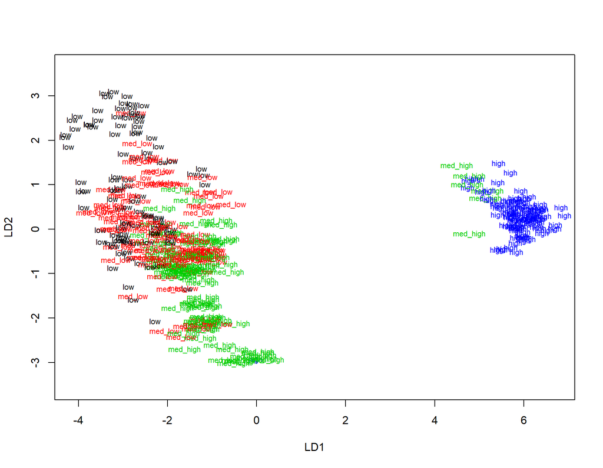

```
##   [1] med_low  med_low  med_low  med_low  med_low  low      low      med_low
##   [9] low      low      med_low  med_low  low      low      med_low  med_low
##  [17] med_low  med_low  med_high med_high med_high med_high med_high med_high
##  [25] med_high med_high med_high med_high med_high med_low  med_low  med_low
##  [33] med_low  med_low  low      low      low      low      med_low  med_low
##  [41] med_low  med_low  med_low  med_high med_high med_high med_low  low
##  [49] med_low  low      low      med_high med_high med_high med_high med_high
##  [57] low      low      low      low      low      low      med_low  low
##  [65] med_low  med_low  med_low  med_low  med_low  low      med_low  med_low
##  [73] low      high     high     high     high     high     high     high
##  [81] high     high     high     high     high     high     high     high
##  [89] high     high     high     high     high     high     high     high
##  [97] high     high     high     med_high med_high med_low
## Levels: low med_low med_high high
```

## Distance measurement

```r
library(MASS)
data('Boston')
boston_scaled <- scale(Boston)
summary(boston_scaled)
```

```
##       crim                 zn               indus              chas
##  Min.   :-0.419367   Min.   :-0.48724   Min.   :-1.5563   Min.   :-0.2723
##  1st Qu.:-0.410563   1st Qu.:-0.48724   1st Qu.:-0.8668   1st Qu.:-0.2723
##  Median :-0.390280   Median :-0.48724   Median :-0.2109   Median :-0.2723
##  Mean   : 0.000000   Mean   : 0.00000   Mean   : 0.0000   Mean   : 0.0000
##  3rd Qu.: 0.007389   3rd Qu.: 0.04872   3rd Qu.: 1.0150   3rd Qu.:-0.2723
##  Max.   : 9.924110   Max.   : 3.80047   Max.   : 2.4202   Max.   : 3.6648
##       nox                rm               age               dis
##  Min.   :-1.4644   Min.   :-3.8764   Min.   :-2.3331   Min.   :-1.2658
##  1st Qu.:-0.9121   1st Qu.:-0.5681   1st Qu.:-0.8366   1st Qu.:-0.8049
##  Median :-0.1441   Median :-0.1084   Median : 0.3171   Median :-0.2790
##  Mean   : 0.0000   Mean   : 0.0000   Mean   : 0.0000   Mean   : 0.0000
##  3rd Qu.: 0.5981   3rd Qu.: 0.4823   3rd Qu.: 0.9059   3rd Qu.: 0.6617
##  Max.   : 2.7296   Max.   : 3.5515   Max.   : 1.1164   Max.   : 3.9566
##       rad               tax             ptratio            black
##  Min.   :-0.9819   Min.   :-1.3127   Min.   :-2.7047   Min.   :-3.9033
##  1st Qu.:-0.6373   1st Qu.:-0.7668   1st Qu.:-0.4876   1st Qu.: 0.2049
##  Median :-0.5225   Median :-0.4642   Median : 0.2746   Median : 0.3808
##  Mean   : 0.0000   Mean   : 0.0000   Mean   : 0.0000   Mean   : 0.0000
##  3rd Qu.: 1.6596   3rd Qu.: 1.5294   3rd Qu.: 0.8058   3rd Qu.: 0.4332
##  Max.   : 1.6596   Max.   : 1.7964   Max.   : 1.6372   Max.   : 0.4406
##      lstat              medv
##  Min.   :-1.5296   Min.   :-1.9063
##  1st Qu.:-0.7986   1st Qu.:-0.5989
##  Median :-0.1811   Median :-0.1449
##  Mean   : 0.0000   Mean   : 0.0000
##  3rd Qu.: 0.6024   3rd Qu.: 0.2683
##  Max.   : 3.5453   Max.   : 2.9865
```

```r
class(boston_scaled)
```

```
## [1] "matrix"
```

```r
boston_scaled<-as.data.frame(boston_scaled)
dist_eu <- dist(boston_scaled)
summary(dist_eu)
```

```
##    Min. 1st Qu.  Median    Mean 3rd Qu.    Max.
##  0.1343  3.4625  4.8241  4.9111  6.1863 14.3970
```

```r
boston_scaled<-as.matrix(boston_scaled, method= "manhattan") # saving the scaled data under manhattan matrix.
dist_man <- dist(boston_scaled)
summary(dist_man)
```

```
##    Min. 1st Qu.  Median    Mean 3rd Qu.    Max.
##  0.1343  3.4625  4.8241  4.9111  6.1863 14.3970
```

## K-means clustering

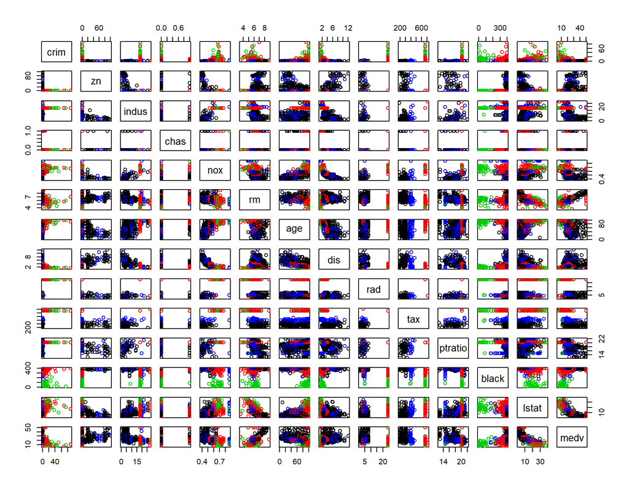

```r
# k-means clustering
km <-kmeans(Boston, centers = 4)
# plot the Boston dataset with clusters
pairs(Boston, col = km$cluster)
```

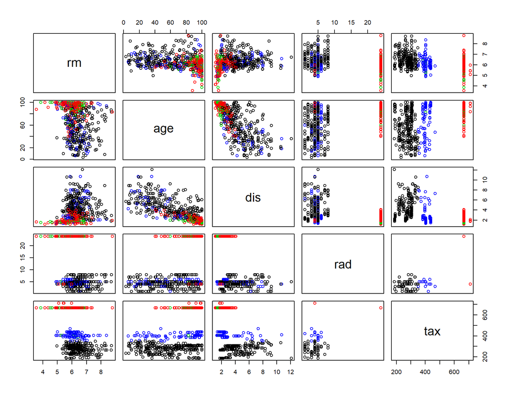

```r
pairs(Boston[6:10], col = km$cluster)
```

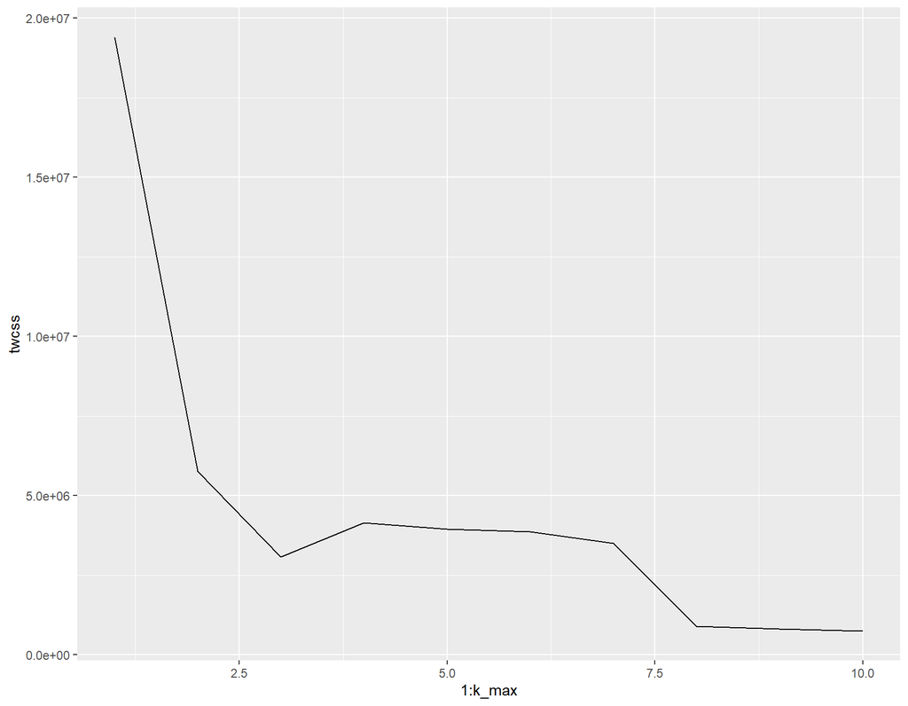

```r
set.seed(123)
k_max <- 10
twcss <- sapply(1:k_max, function(k){kmeans(Boston, k)$tot.withinss})
qplot(x = 1:k_max, y = twcss, geom = 'line')
```

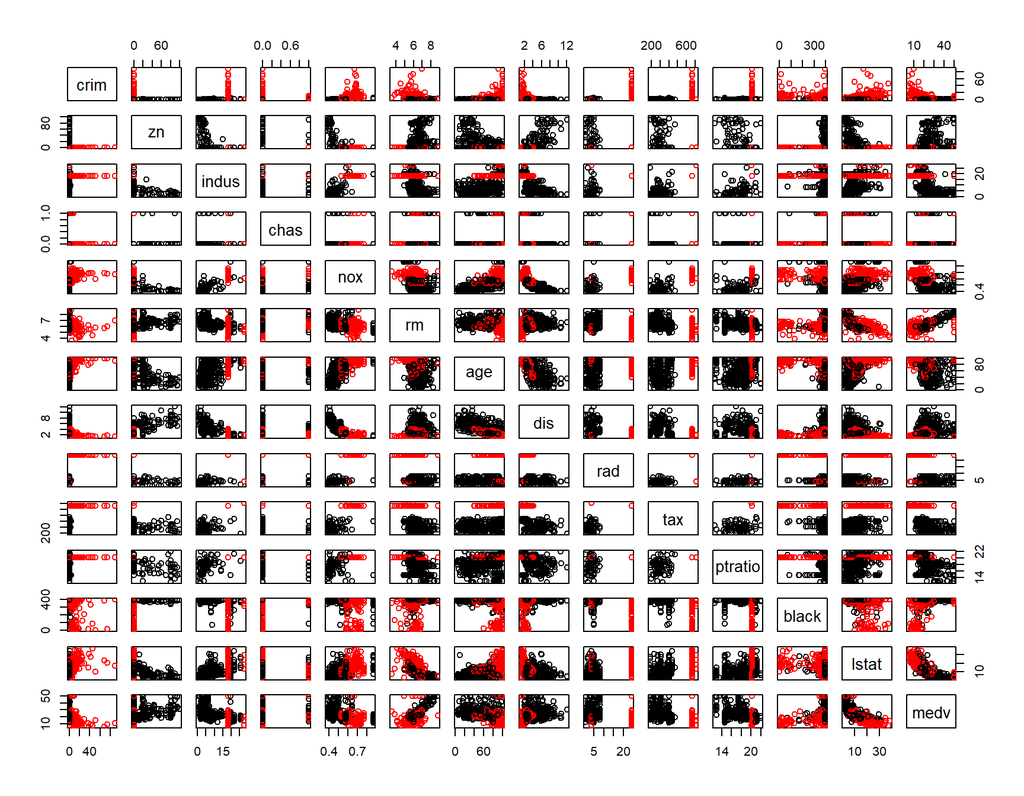

```r
km <-kmeans(Boston, centers = 2)
pairs(Boston, col = km$cluster)
```

## Bonus

```r
library(MASS)
data(Boston) # load the Boston data set
boston_scaled1<- scale(Boston)# scale the Boston data set again - named boston_scaled1
boston_scaled2<-as.data.frame(boston_scaled1)
km1 <-kmeans(Boston, centers = 3)# k-means clustering

cluster <- km1$cluster
boston_scaled2<- data.frame(boston_scaled1,cluster) # add the cluster number to the df
lda.fit<- lda(cluster~., data = boston_scaled2)#linear discriminant analysis of clusters vs. all other variables
lda.fit# print the lda.fit object
```

```
## Call:
## lda(cluster ~ ., data = boston_scaled2)
##
## Prior probabilities of groups:
##         1         2         3
## 0.5296443 0.1996047 0.2707510
##
## Group means:
##         crim          zn      indus          chas        nox         rm
## 1 -0.3920779  0.27670879 -0.6513071  0.0214843827 -0.6152775  0.2573427
## 2 -0.3293317 -0.07332724  0.2818828  0.0005392655  0.2816899 -0.1453417
## 3  1.0097765 -0.48724019  1.0662784 -0.0424254043  0.9959393 -0.3962652
##          age        dis        rad         tax    ptratio       black
## 1 -0.4572006  0.5121870 -0.6013344 -0.78136288 -0.2690134  0.34109296
## 2  0.1822823 -0.2378455 -0.5418150 -0.01444889 -0.3768823  0.07010933
## 3  0.7599946 -0.8265965  1.5757732  1.53915759  0.8040926 -0.71893398
##         lstat        medv
## 1 -0.43621538  0.36234147
## 2  0.01371321 -0.03812375
## 3  0.84321670 -0.68070813
##
## Coefficients of linear discriminants:
##                  LD1         LD2
## crim     0.048210477  0.05079118
## zn       0.253528315  0.06311589
## indus    0.369497254  0.12674727
## chas    -0.047064817  0.01998369
## nox     -0.063156250 -0.49621758
## rm      -0.005144383  0.09537352
## age     -0.118710969  0.05412142
## dis     -0.385151599  0.17969944
## rad      1.996321584  3.05733525
## tax      4.535785039 -2.77688761
## ptratio  0.122064688  0.19196217
## black   -0.029200518  0.06353722
## lstat    0.085030308  0.12666624
## medv     0.157444662 -0.10356584
##
## Proportion of trace:
##    LD1    LD2
## 0.9812 0.0188
```

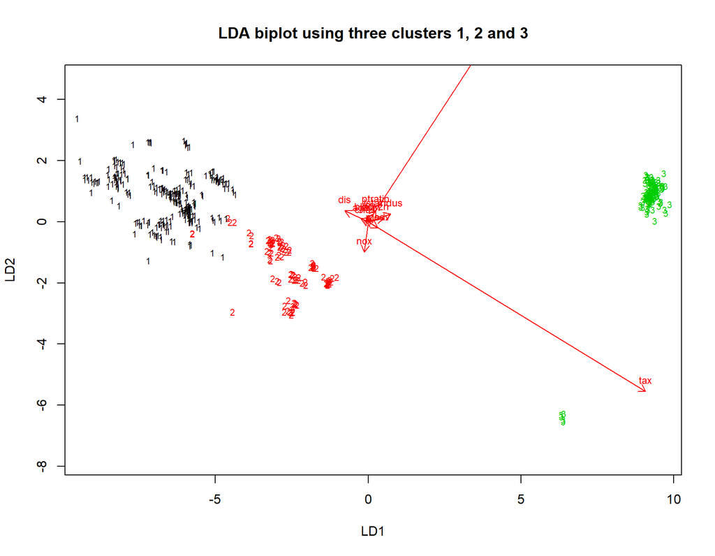

```r
# the function for lda biplot arrows
lda.arrows <- function(x, myscale = 1, arrow_heads = 0.1, color = "red", tex = 0.75, choices = c(1,2)){
  heads <- coef(x)
  arrows(x0 = 0, y0 = 0,
         x1 = myscale * heads[,choices[1]],
         y1 = myscale * heads[,choices[2]], col=color, length = arrow_heads)
  text(myscale * heads[,choices], labels = row.names(heads),
       cex = tex, col=color, pos=3)
}

classes1 <- as.numeric(boston_scaled2$cluster)# target classes as numeric

plot(lda.fit, dimen = 2, col = classes1, pch = classes1, main = "LDA biplot using three clusters 1, 2 and 3")# plot the lda results
lda.arrows(lda.fit, myscale = 2)
```

# Chapter5:Dimensionality reduction techniques